# Effect of the neighbourhood quality on the apartment rent

## Introduction

The value of an apartment depends on more than the location and the characteristics of a apartment. It also depends on the neighbourhood and the mobility. The aim of this project is to analyse the quality of a neighbourhood and the effect on the apartment rent.

For example if an investor has a list of apartments which are available for sale he would probably only want to invest in an apartment that is located in a good neighboorhood. Evaluating the neighbourhood requires a lot of local knowledge or some research about it. If the quality of the neighbourhood could be evaluated by the foursquare data instead, this could save a lot of time and would help to evaluate the apartments automatically.

## Data description

The foursuqare data is used to evaluate the quality of the neighbourhood. Therefore the following categories are used:

- nearby public transportations
- schools / universities
- cultural venues
- food venues
- nightlife
- nature and spare time

are analysed.

The apartment data consists of the apartment base rent and additional information like latitude, longitude, square feet etc.

## Methodology

To analyse the neighbourhood of the apartments, the number of venues in each category are evaluated for each apartment. Afterwards, the correlation between number of venue and the average base rent per square meter is shown in a box plot, to get the average values and remove the outliers

## Preparation

First we need to import the required packages that we us in this project and initialize the foursqure credentials

```python
import requests # library to handle requests
import pandas as pd # library for data analsysis
import numpy as np # library to handle data in a vectorized manner
from geopy.geocoders import Nominatim # module to convert an address into latitude and longitude values
import folium # plotting library

import matplotlib.pyplot as plt
import seaborn as sns
```

```python
CLIENT_ID = '' # your Foursquare ID
CLIENT_SECRET = '' # your Foursquare Secret
VERSION = '20191129'
LIMIT = 30
print('Your credentails:')
print('CLIENT_ID: ' + CLIENT_ID)
print('CLIENT_SECRET:' + CLIENT_SECRET)
```

```
Your credentails:
CLIENT_ID:
CLIENT_SECRET:
```

Now we need to read the apartment data from a csv file and display some entries and the data types

```python
apartments_df = pd.read_csv('Rohdaten/Final.csv',delimiter=';')
apartments_df.head()
```

|  | Unnamed: 0 | URL | beschreibung | evt_count_pm_sig | ga_cd_application_requirements | ga_cd_cxp_historicallisting | ga_cd_developer_virtualreality | ga_cd_maillead_default_shown | ga_cd_via | ga_cd_via_qualified | ... | obj_telekomTrackingGroup | obj_telekomTvOffer | obj_telekomUploadSpeed | obj_thermalChar | obj_totalRent | obj_typeOfFlat | obj_yearConstructed | obj_yearConstructedRange | obj_zipCode | timestamp |
| --- | --- | --- | --- | --- | --- | --- | --- | --- | --- | --- | --- | --- | --- | --- | --- | --- | --- | --- | --- | --- | --- |
| 0 | 0 | /expose/114319641 | ['Das Grundstück besteht aus einem Vorder- und... | showqualicontactform | profile0 | False | NaN | True | schaufenster | True | ... | telekom_layer_magenta_l | ONE_YEAR_FREE | 40 MBit/s | 138.3 | 540.00 | apartment | 1900,0 | 1,0 | 4275,0 | 2020-01-01 14:09:49.583239 |
| 1 | 1 | /expose/114842629 | ['Ihr neues Zuhause finden Sie hier! Das Dunck... | showqualicontactform | profile0 | False | NaN | True | schaufenster | True | ... | telekom_layer_magenta_l | ONE_YEAR_FREE | 40 MBit/s | NaN | 653.98 | no_information | 1954,0 | 2,0 | 4179,0 | 2020-01-01 14:09:50.043289 |
| 2 | 2 | /expose/110886227 | ['Raum für alles, Freiraum für jeden: Das neu ... | showqualicontactform | profile0 | False | NaN | True | schaufenster | NaN | ... | telekom_layer_magenta_l | ONE_YEAR_FREE | 40 MBit/s | NaN | 1027.16 | apartment | 2018,0 | 9,0 | 4103,0 | 2020-01-01 14:09:50.511619 |
| 3 | 3 | /expose/104206819 | ['Sanierte Wohnsiedlung in denkmalgeschützter ... | showqualicontactform | profile0 | False | NaN | True | premium | True | ... | telekom_layer_magenta_l | ONE_YEAR_FREE | 40 MBit/s | 109.0 | 520.00 | no_information | 1930,0 | 1,0 | 4157,0 | 2020-01-01 14:09:51.603305 |
| 4 | 4 | /expose/115104446 | ['Zwischen dem Bayerischen Bahnhof und der Alt... | showqualicontactform | profile0 | False | NaN | True | premium | True | ... | telekom_layer_magenta_l | ONE_YEAR_FREE | 40 MBit/s | NaN | 610.00 | no_information | 1970,0 | 2,0 | 4103,0 | 2020-01-01 14:09:52.119462 |

5 rows × 88 columns

```python
columns= {"geo_plz","obj_baseRent","obj_regio3","obj_street","lat","long","obj_livingSpace"}
apartments_df= apartments_df[columns]
apartments_df.dtypes
```

```
obj_regio3          object
long                object
obj_street          object
obj_baseRent       float64
geo_plz             object
obj_livingSpace    float64
lat                 object
dtype: object
```

## Data preparation

To use the data for the statistical analysis we need to prepare it in terms of encoding and format.

At first, the latitude and longitude values needs to be edited

```python
apartments_df['lat'] = apartments_df['lat'].str.replace(",",".")
apartments_df['long'] = apartments_df['long'].str.replace(",",".")
```

### Remove all apartments outside of Leipzig

To remove all aparatments which lie outside of Leipzig we first need to find all districts of Leipzig. For that we load the geojson file of Leizig an read all available districts

```python
import json #(geojson also fine)

districts = []
filename = 'ortsteile.json'

json_data = open(filename,encoding="utf-8")
data = json.load(json_data)
for feature in data['features']:
    districts.append(feature['properties']['Name'])
districts
```

```
['Zentrum',
 'Zentrum-Ost',
 'Zentrum-Südost',
 'Zentrum-Süd',
 'Zentrum-West',
 'Zentrum-Nordwest',
 'Zentrum-Nord',
 'Schönefeld-Abtnaundorf',
 'Schönefeld-Ost',
 'Mockau-Süd',
 'Mockau-Nord',
 'Thekla',
 'Plaußig-Portitz',
 'Neustadt-Neuschönefeld',
 'Volkmarsdorf',
 'Anger-Crottendorf',
 'Sellerhausen-Stünz',
 'Paunsdorf',
 'Heiterblick',
 'Mölkau',
 'Engelsdorf',
 'Baalsdorf',
 'Althen-Kleinpösna',
 'Reudnitz-Thonberg',
 'Stötteritz',
 'Probstheida',
 'Meusdorf',
 'Liebertwolkwitz',
 'Holzhausen',
 'Südvorstadt',
 'Connewitz',
 'Marienbrunn',
 'Lößnig',
 'Dölitz-Dösen',
 'Schleußig',
 'Plagwitz',
 'Kleinzschocher',
 'Großzschocher',
 'Knautkleeberg-Knauthain',
 'Hartmannsdorf-Knautnaundorf',
```

[output cut: 8 more lines]

```
 'Altlindenau',
 'Neulindenau',
 'Leutzsch',
 'Böhlitz-Ehrenberg',
 'Burghausen-Rückmarsdorf',
 'Möckern',
 'Wahren',
 'Lützschena-Stahmeln',
 'Lindenthal',
 'Gohlis-Süd',
 'Gohlis-Mitte',
 'Gohlis-Nord',
 'Eutritzsch',
 'Seehausen',
 'Wiederitzsch']
```

Now that we have all districts of Leipzig we can remove all apartments which lie outside of these districts. But first we need to analyse all the outliers to make sure there are no encoding errors.

```python
 apartments_df[~apartments_df.obj_regio3.isin(districts)].obj_regio3
```

```
3          Gohlis_Nord
4       Zentrum_Südost
6       Zentrum_Südost
9          Zentrum_Süd
11         Gohlis_Nord
             ...
3973            Böhlen
3974      Markranstädt
3975            Grimma
3976      Markkleeberg
3979        Mockau_Süd
Name: obj_regio3, Length: 2133, dtype: object
```

We can see that we need to replace all "_" with "-" since the geojson file uses a different format.

```python
apartments_df['obj_regio3'] = apartments_df['obj_regio3'].str.replace("_","-")

apartments_df[~apartments_df.obj_regio3.isin(districts)].obj_regio3
```

```
831     Knauthain-Knautkleeberg
1312    Knauthain-Knautkleeberg
1314    Knauthain-Knautkleeberg
1879    Knauthain-Knautkleeberg
2305    Knauthain-Knautkleeberg
2369    Knauthain-Knautkleeberg
3814    Knauthain-Knautkleeberg
3960                     Grimma
3961                     Böhlen
3962              Neukieritzsch
3963                     Taucha
3964               Markkleeberg
3965               Markkleeberg
3966                 Schkeuditz
3967              Neukieritzsch
3968               Markranstädt
3969                  Delitzsch
3970                    Naunhof
3971                  Eilenburg
3972                  Zschadraß
3973                     Böhlen
3974               Markranstädt
3975                     Grimma
3976               Markkleeberg
Name: obj_regio3, dtype: object
```

Next, we need to replace "Knauthain-Knautkleeberg" with "Knautkleeberg-Knauthain"

```python
apartments_df['obj_regio3'] = apartments_df['obj_regio3'].str.replace("Knauthain-Knautkleeberg","Knautkleeberg-Knauthain")
apartments_df[~apartments_df.obj_regio3.isin(districts)].obj_regio3
```

```
3960           Grimma
3961           Böhlen
3962    Neukieritzsch
3963           Taucha
3964     Markkleeberg
3965     Markkleeberg
3966       Schkeuditz
3967    Neukieritzsch
3968     Markranstädt
3969        Delitzsch
3970          Naunhof
3971        Eilenburg
3972        Zschadraß
3973           Böhlen
3974     Markranstädt
3975           Grimma
3976     Markkleeberg
Name: obj_regio3, dtype: object
```

The rest of the entries are smaller places in the surrounding area of Leipzig and can be removed.

```python
apartments_df = apartments_df[apartments_df.obj_regio3.isin(districts)]
```

```python
apartments_df['rel_baseRent'] = apartments_df['obj_baseRent'].div(apartments_df['obj_livingSpace'], axis=0)
apartments_df.head()
```

|  | obj_regio3 | long | obj_street | obj_baseRent | geo_plz | obj_livingSpace | lat | rel_baseRent |
| --- | --- | --- | --- | --- | --- | --- | --- | --- |
| 0 | Südvorstadt | 12.367475509050035 | Brandvorwerkstra&szlig;e | 449.00 | 4275,0 | 38.00 | 51.31917954718799 | 11.815789 |
| 1 | Neulindenau | 12.308628850854303 | Mansfelder Weg | 485.21 | 4179,0 | 70.32 | 51.335769128666705 | 6.900028 |
| 2 | Engelsdorf | 12.475476585419749 | Querstra&szlig;e | 847.27 | 4103,0 | 79.24 | 51.3347544576297 | 10.692453 |
| 3 | Gohlis-Nord | 12.36387902280009 | Norderneyer Weg | 370.00 | 4157,0 | 64.00 | 51.378125158388826 | 5.781250 |
| 4 | Zentrum-Südost | 12.383587200711078 | Stra&szlig;e des 18. Oktober | 445.00 | 4103,0 | 71.43 | 51.32821612102798 | 6.229875 |

## Analyse the data

First we visualize the data by showing the locations on the map of leipzig

```python
from folium.plugins import FastMarkerCluster


address = 'Leipzig, DE'

geolocator = Nominatim(user_agent="leipzig_explorer")
location = geolocator.geocode(address)
latitude = location.latitude
longitude = location.longitude
print('The geograpical coordinate of leipzig are {}, {}.'.format(latitude, longitude))

fast_map_leipzig = folium.Map(location=[latitude, longitude], zoom_start=12)

# add all the point from the file to the map object using FastMarkerCluster
fast_map_leipzig.add_child(FastMarkerCluster(data= apartments_df[['lat', 'long','rel_baseRent']].values.tolist()))
fast_map_leipzig
```

```
The geograpical coordinate of leipzig are 51.3406321, 12.3747329.
```

[interactive chart not shown]

The map shows that the data has a good distribution of the apartments in Leipzig. There are more apartments in the center of Leipzig but the data contains apartments for all districts. Since some districts are more trending than others, which effects the apartment rent, we can analyse the average apartment rent for each district.

Therefore, the entries can be grouped by the district and the rent per square meter can be averaged.

```python
avg_rent = apartments_df[{'rel_baseRent','obj_regio3'}].groupby(['obj_regio3'], as_index=False).mean()

avg_rent.head(10)
```

|  | obj_regio3 | rel_baseRent |
| --- | --- | --- |
| 0 | Althen-Kleinpösna | 5.909091 |
| 1 | Altlindenau | 7.275191 |
| 2 | Anger-Crottendorf | 7.529596 |
| 3 | Baalsdorf | 6.849315 |
| 4 | Burghausen-Rückmarsdorf | 6.608364 |
| 5 | Böhlitz-Ehrenberg | 7.277148 |
| 6 | Connewitz | 10.919297 |
| 7 | Dölitz-Dösen | 7.554143 |
| 8 | Engelsdorf | 7.704958 |
| 9 | Eutritzsch | 7.952288 |

```python
map_leipzig = folium.Map(location=[latitude, longitude], zoom_start=11)


folium.Choropleth(
    geo_data=data,
    name='choropleth',
    data=avg_rent,
    columns=['obj_regio3', 'rel_baseRent'],
    key_on='feature.properties.Name',
    fill_color='YlGn',
    fill_opacity=0.7,
    line_opacity=0.2,
    legend_name='Average rent per square meter'
).add_to(map_leipzig)

folium.LayerControl().add_to(map_leipzig)


map_leipzig
```

[interactive chart not shown]

As we can see, the center of Leipzig has a higher average rent per square meter than the districts in ther outer area of Leipzig.

## Analyse the neighbourhood effect with foursquare

This section uses the foursquare api to analyse the neightbourhood of each apartment. Therefore, the venues for different categories are requested.

First, we analyse the public transportation possibilities for each apartment.

```python
apartments_df['transportations'] = 0
for index, row in apartments_df.iterrows():
    long = float(row['long'])
    lat = float(row['lat'])
    url = 'https://api.foursquare.com/v2/venues/explore?client_id={}&client_secret={}&ll={},{}&v={}&radius={}&limit={}&categoryId={}'.format(CLIENT_ID, CLIENT_SECRET, lat, long, VERSION, 500, 50,'4d4b7105d754a06379d81259')
    results = requests.get(url).json()
    if(len(results['response'])==0):
        continue
    number_of_stations = len(results['response']['groups'][0]['items'])
    print('There are {} transportation venues around.'.format(number_of_stations))
    apartments_df['transportations'][index] = number_of_stations
```

```python
apartments_df.head()
```

[output not shown]

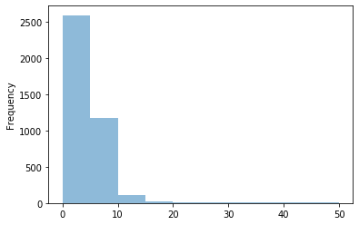

```python
apartments_df['transportations'].plot.hist(bins=10,alpha=0.5)
```

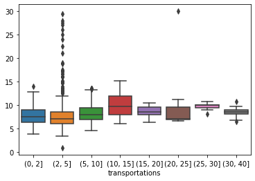

```python
cut = pd.cut(apartments_df.transportations, [0, 2, 5, 10, 15, 20, 25, 30, 40])

boxdf = apartments_df.groupby(cut).apply(lambda apartments_df: apartments_df.rel_baseRent.reset_index(drop=True)).unstack(0)

sns.boxplot(data=boxdf);
```

The next categorie is culture, since areas with more cultural venues should be more trending than others.

```python
apartments_df['culture'] = 0
for index, row in apartments_df.iterrows():
    long = float(row['long'])
    lat = float(row['lat'])
    url = 'https://api.foursquare.com/v2/venues/explore?client_id={}&client_secret={}&ll={},{}&v={}&radius={}&limit={}&categoryId={}'.format(CLIENT_ID, CLIENT_SECRET, lat, long, VERSION, 500, 50,'4d4b7104d754a06370d81259')
    results = requests.get(url).json()
    if(len(results['response'])==0):
        print("no results")
        continue
    number_of_venues = len(results['response']['groups'][0]['items'])
    print('There are {} culture venues around.'.format(number_of_venues))
    apartments_df['culture'][index] = number_of_venues
```

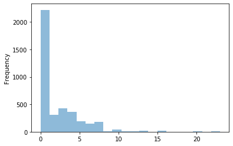

```python
apartments_df['culture'].plot.hist(bins=20, alpha=0.5)
```

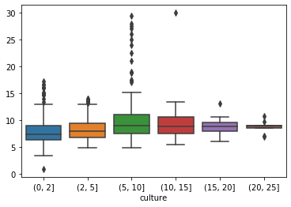

```python
cut = pd.cut(apartments_df.culture, [0, 2, 5, 10, 15, 20, 25, 30, 40])

boxdf = apartments_df.groupby(cut).apply(lambda apartments_df: apartments_df.rel_baseRent.reset_index(drop=True)).unstack(0)

sns.boxplot(data=boxdf);
```

As expected, the number of cultural venues has an effect on the apartment rent. The graph also shows that the average rent per square meter stops increasing after 5-10 cultural venues but this could be caused by the low number of apartments with a high number of venues in the neighbourhood. Another interesting part in this graph are the outliers. The apartments with less or no cultural venues have lower outliers than the apartments with 5-10 cultural venues in the neighbourhood.

The next analysis uses the university venues, since areas with a lot university venues should also be more trending.

```python
apartments_df['university'] = 0
for index, row in apartments_df.iterrows():
    long = float(row['long'])
    lat = float(row['lat'])
    url = 'https://api.foursquare.com/v2/venues/explore?client_id={}&client_secret={}&ll={},{}&v={}&radius={}&limit={}&categoryId={}'.format(CLIENT_ID, CLIENT_SECRET, lat, long, VERSION, 500, 50,'4d4b7105d754a06372d81259')
    results = requests.get(url).json()
    if(len(results['response'])==0):
        print("no results")
        continue
    number_of_venues = len(results['response']['groups'][0]['items'])
    print('There are {} university venues around.'.format(number_of_venues))
    apartments_df['university'][index] = number_of_venues
```

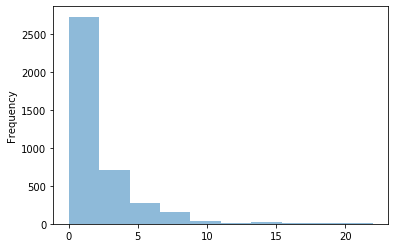

```python
apartments_df['university'].plot.hist(bins=10, alpha=0.5)
```

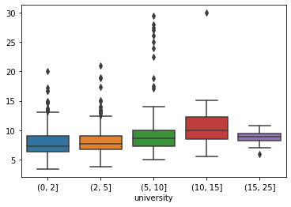

```python
cut = pd.cut(apartments_df.university, [0, 2, 5, 10, 15, 25])

boxdf = apartments_df.groupby(cut).apply(lambda apartments_df: apartments_df.rel_baseRent.reset_index(drop=True)).unstack(0)

sns.boxplot(data=boxdf);
```

As expected, the number of university venues has also an effect on the average apartment rent. Again, the group with the highest number of university venues has not the highest average rent but this could be because of the less number of entries.

As next, the food venues are analysed

```python
apartments_df['food'] = 0
for index, row in apartments_df.iterrows():
    long = float(row['long'])
    lat = float(row['lat'])
    url = 'https://api.foursquare.com/v2/venues/explore?client_id={}&client_secret={}&ll={},{}&v={}&radius={}&limit={}&categoryId={}'.format(CLIENT_ID, CLIENT_SECRET, lat, long, VERSION, 500, 50,'4d4b7105d754a06374d81259')
    results = requests.get(url).json()
    if(len(results['response'])==0):
        print("no results")
        continue
    number_of_venues = len(results['response']['groups'][0]['items'])
    print('There are {} food venues around.'.format(number_of_venues))
    apartments_df['food'][index] = number_of_venues
```

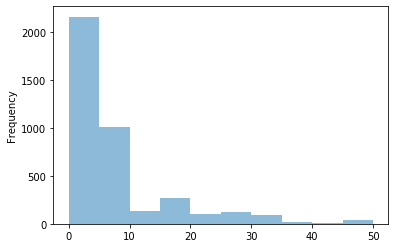

```python
apartments_df['food'].plot.hist(bins=10, alpha=0.5)
```

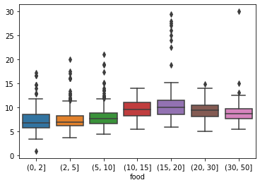

```python
cut = pd.cut(apartments_df.food, [0, 2, 5, 10, 15, 20, 30, 50])

boxdf = apartments_df.groupby(cut).apply(lambda apartments_df: apartments_df.rel_baseRent.reset_index(drop=True)).unstack(0)

sns.boxplot(data=boxdf);
```

As in the previous analysis the average rent per square meter increases with an increasing numbers of venues.

The next analysis uses the nightlife venues

```python
apartments_df['nightlife'] = 0
for index, row in apartments_df.iterrows():
    long = float(row['long'])
    lat = float(row['lat'])
    url = 'https://api.foursquare.com/v2/venues/explore?client_id={}&client_secret={}&ll={},{}&v={}&radius={}&limit={}&categoryId={}'.format(CLIENT_ID, CLIENT_SECRET, lat, long, VERSION, 500, 50,'4d4b7105d754a06376d81259')
    results = requests.get(url).json()
    if(len(results['response'])==0):
        print("no results")
        continue
    number_of_venues = len(results['response']['groups'][0]['items'])
    print('There are {} nightlife venues around.'.format(number_of_venues))
    apartments_df['nightlife'][index] = number_of_venues
```

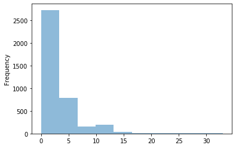

```python
apartments_df['nightlife'].plot.hist(bins=10, alpha=0.5)
```

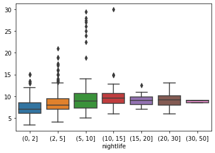

```python
cut = pd.cut(apartments_df.nightlife, [0, 2, 5, 10, 15, 20, 30, 50])

boxdf = apartments_df.groupby(cut).apply(lambda apartments_df: apartments_df.rel_baseRent.reset_index(drop=True)).unstack(0)

sns.boxplot(data=boxdf);
```

And finally the analysis with the sparetime venues

```python
apartments_df['spareTime'] = 0
for index, row in apartments_df.iterrows():
    long = float(row['long'])
    lat = float(row['lat'])
    url = 'https://api.foursquare.com/v2/venues/explore?client_id={}&client_secret={}&ll={},{}&v={}&radius={}&limit={}&categoryId={}'.format(CLIENT_ID, CLIENT_SECRET, lat, long, VERSION, 500, 50,'4d4b7105d754a06377d81259')
    results = requests.get(url).json()
    if(len(results['response'])==0):
        print("no results")
        continue
    number_of_venues = len(results['response']['groups'][0]['items'])
    print('There are {} spareTime venues around.'.format(number_of_venues))
    apartments_df['spareTime'][index] = number_of_venues
```

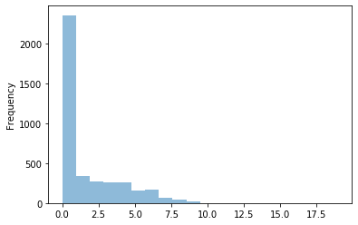

```python
apartments_df['spareTime'].plot.hist(bins=20, alpha=0.5)
```

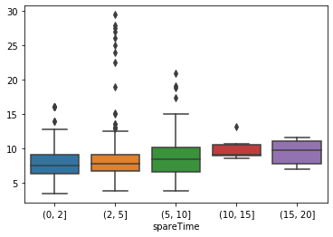

```python
cut = pd.cut(apartments_df.spareTime, [0, 2, 5, 10, 15, 20, 30, 50])

boxdf = apartments_df.groupby(cut).apply(lambda apartments_df: apartments_df.rel_baseRent.reset_index(drop=True)).unstack(0)

sns.boxplot(data=boxdf);
```

## Discussion

All analysis show an increase of the average rent per square meter regarding to the number of the venues for a specific category. But not only the average rent has increased, but also the outliers often increase with the number of venues. The graphs also show that increase stops at a given value and even decrease in a few cases but thats probably because of the low number of samples. This should be further analysed with more samples to get more reliable results

All in all the analysis show that the foursquare data can be used for more precise prediction of the rent of a apartment besides the apartment specific characterics like number of rooms or square meter. It also shows that the rent differs from neighbourhood to neighbourhood.

## Conclusion

This analysis shows that the neighbourhood has an effect on the average rent per square meter and that this effect can also be quantified and further be used as the other characteristics of an apartment to predict the rent.

```python
apartments_df.to_csv("Foursquare.csv",sep=";",encoding="utf-8",decimal=",")
```

```python
apartments_df = pd.read_csv('Foursquare.csv',delimiter=';', index_col=0, encoding="utf-8", decimal=",")
apartments_df.head()
```

|  | obj_regio3 | long | obj_street | obj_baseRent | geo_plz | obj_livingSpace | lat | rel_baseRent | culture | s-stations | university | food | nightlife | spareTime |
| --- | --- | --- | --- | --- | --- | --- | --- | --- | --- | --- | --- | --- | --- | --- |
| 0 | Südvorstadt | 12.367475509050035 | Brandvorwerkstra&szlig;e | 449.00 | 4275.0 | 38.00 | 51.31917954718799 | 11.815789 | 8 | 0 | 0 | 11 | 3 | 5 |
| 1 | Neulindenau | 12.308628850854303 | Mansfelder Weg | 485.21 | 4179.0 | 70.32 | 51.335769128666705 | 6.900028 | 2 | 0 | 0 | 0 | 0 | 1 |
| 2 | Engelsdorf | 12.475476585419749 | Querstra&szlig;e | 847.27 | 4103.0 | 79.24 | 51.3347544576297 | 10.692453 | 0 | 0 | 0 | 4 | 1 | 2 |
| 3 | Gohlis-Nord | 12.36387902280009 | Norderneyer Weg | 370.00 | 4157.0 | 64.00 | 51.378125158388826 | 5.781250 | 0 | 0 | 0 | 4 | 1 | 0 |
| 4 | Zentrum-Südost | 12.383587200711078 | Stra&szlig;e des 18. Oktober | 445.00 | 4103.0 | 71.43 | 51.32821612102798 | 6.229875 | 2 | 1 | 6 | 4 | 4 | 1 |